# Islamaphobia

## Learning Goals:

1. Explain why Islam in particular poses different cultural threats to different segments of the native population
2. Describe the political implications of this double dilemma for promoting inclusive societies

## Establishing the Problem

It seems almost self-evident that Muslims face an especially heavy burden of prejudice in European societies.

Take for instance this clever study by Hainmueller et al. (which we’ll read about in Week 12):

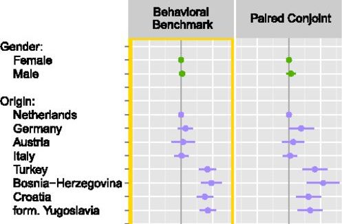

**Questions:**

1. Why is evidence of prejudice and discrimination against immigrants from Muslim-majority countries not necessarily the same as specifically **anti-Muslim** prejudice?
   - Hint: think back to our discussion of compound treatments
2. What do Adida et al. do in order to establish causal evidence of Islamaphobia?

## A Double Opposition

According to Helbling and Traunmüller, modern societies hold values that emphasize individual freedom, gender equality and political secularism.

1. What does this have to do with Islamaphobia?
2. What do H+T mean when they say that Muslims face a double opposition in Western societies?

**Here’s their survey experiment:**

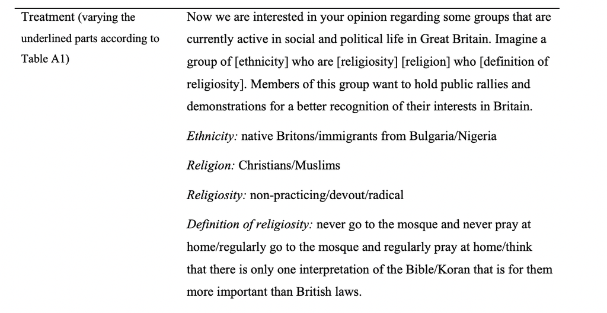

**How would you summarize the following results?**

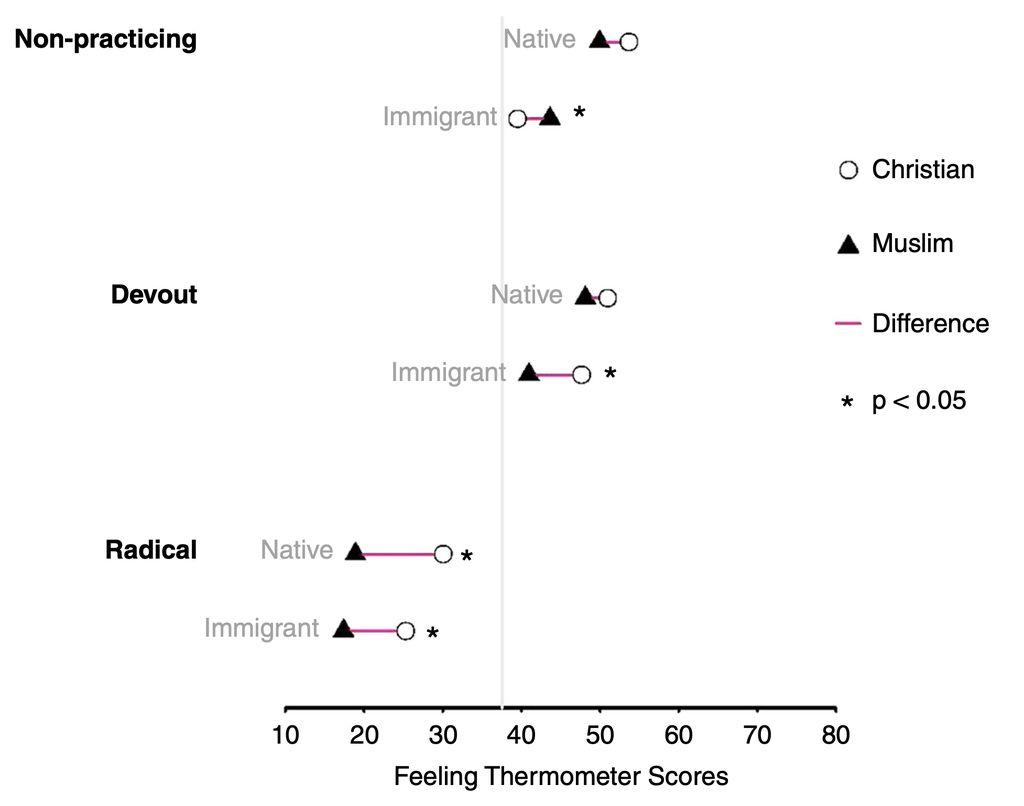

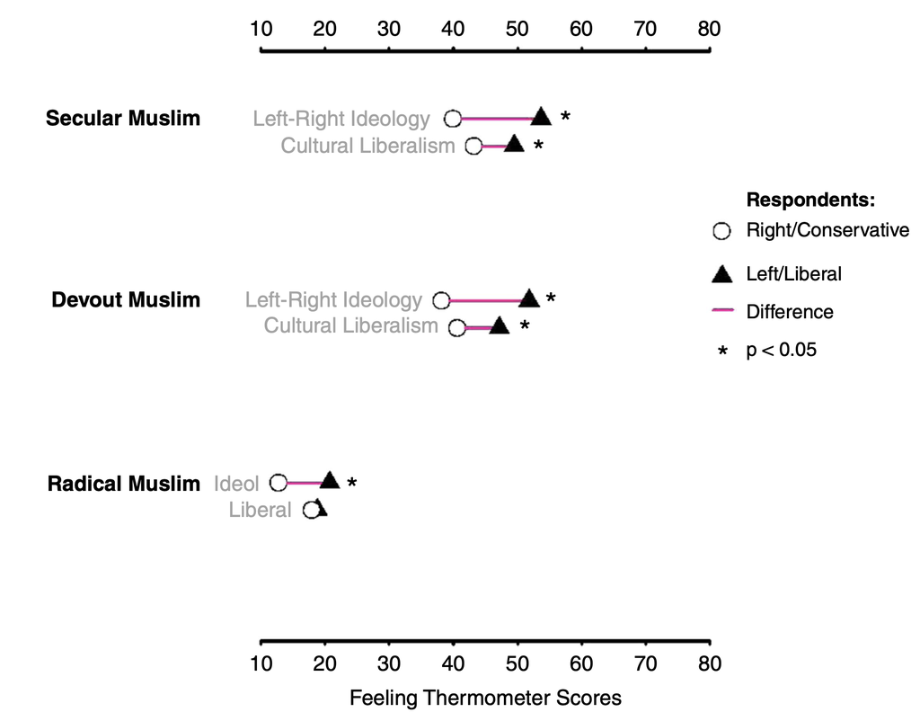

## Political Consequences

**Key question from your reading:** Given that left-wing and right-wing natives both dislike Muslims, why do Isvarflaten and Snidermann argue for focusing on the attitudes of left-wing citizens?

### Public Rally Experiment:

**Prompt:** Should Muslims be allowed to hold a public event to ______

- explain Islamic values
- preach Islamic values
- explain conservative ideas about women
- preach conservative ideas about women

In the baseline condition, majority citizens were asked whether “Muslims should be allowed to hold a public event to explain Islamic values”; in a second condition, they were asked whether they should be allowed to do so “to preach” Islamic values; in a third condition, “to explain conserva- tive ideas about women”; in a final condition, “to preach conservative ideas about women.”

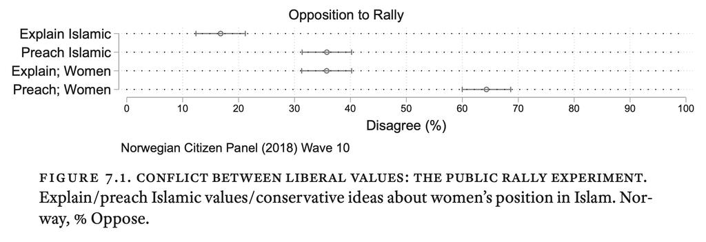

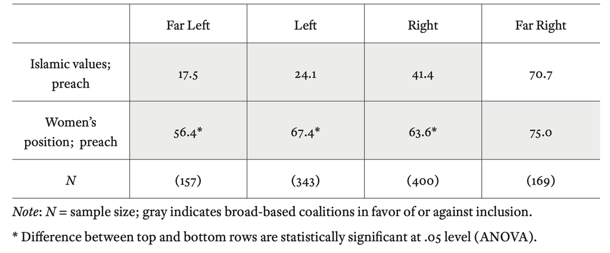

**Why this is important** (I+S pp.10-11):

Against a background of the far right gaining electoral ground and amassing political influence by targeting Islam and Muslim minorities as an existential threat, there is a natural concern that efforts to promote inclusion may fan the fires already burning. Hence the importance of identifying which political options are most likely to win broad support for inclusion, and which are most likely to set back inclusion.

A polarization trap…[exists] when majorities in favor of inclusion exist, but they are misunderstood as majorities in favor of exclusion because political actors have not recognized that support for inclusion is conditional on the particular terms on which it is proposed.